# ADL_Group_45_Task1_CIFAR10

## Advanced Deep Learning (S1-24_AIMLCZG513)

## ADL Group 45

### Contribution

1. Hemant Kumar Parakh (2023AA05741)
2. Sushil Kumar (2023aa05849)
3. Jitendra Kumar (2023aa05198)
4. PARTH VASHISHTHA (2023ab05104)

Dataset Name - CIFAR10

## Assignment 2 - Experiment with GAN

- Task 1: Implement and train a conditional Wesserstein GAN with CIFAR10 dataset. Generate and display 10 new images belonging to 'automobile' class. Report IS and FID scores.
- Task 2: Implement and train a SNGAN with CIFAR10 dataset. Generate and display 10 new images. Report IS and FID scores.
- Task 3: Implement and train a variant of SAGAN without spectral normalization and TTUB with CIFAR10 dataset. Generate 10 new images. Report IS and FID scores.
- Task 4: Implement and train a complete SAGAN with CIFAR10 dataset. Generate and display 10 new images. Report IS and FID scores.
- Task 5: Summarize your observations.

## Imports

```python
import os
import numpy as np
import tensorflow as tf
import matplotlib.pyplot as plt
from tensorflow.keras.layers import (Input, Dense, Reshape, Flatten, Conv2D, Conv2DTranspose, LeakyReLU, BatchNormalization, Embedding, Concatenate)
from tensorflow.keras.models import Model
from tensorflow.keras.optimizers import Adam
from tensorflow.keras.datasets import cifar10
from tensorflow.keras.initializers import RandomNormal
from tensorflow.keras.applications.inception_v3 import InceptionV3
from tensorflow.keras.applications.inception_v3 import preprocess_input as inception_preprocess
from scipy.linalg import sqrtm
import cv2
from tensorflow.keras.utils import plot_model  # Import plot_model

#print(preprocess_input)

# Check for GPU availability
print("Num GPUs Available:", len(tf.config.list_physical_devices('GPU')))
```

```
Num GPUs Available: 1
```

## Load CIFAR-10 dataset

```python
# Load CIFAR-10 dataset
(x_train, y_train), (_, _) = cifar10.load_data()

# Select only "automobile" class (label 1)
auto_indices = np.where(y_train.flatten() == 1)[0]
x_train = x_train[auto_indices]
y_train = y_train[auto_indices]

# Normalize images to [0, 1] for compatibility with InceptionV3
x_train = (x_train.astype(np.float32)) / 255.0
```

```
Downloading data from https://www.cs.toronto.edu/~kriz/cifar-10-python.tar.gz
170498071/170498071 ━━━━━━━━━━━━━━━━━━━━ 4s 0us/step
```

## Display of original images from belonging to 'automobile' class

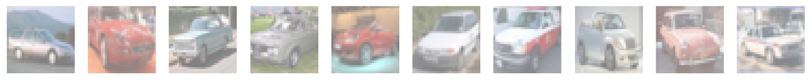

```python
# Display original automobile images
def display_original_images():
    fig, axes = plt.subplots(1, 10, figsize=(15, 3))
    for i in range(10):
        axes[i].imshow((x_train[i] * 127.5 + 127.5).astype(np.uint8))
        axes[i].axis('off')
    plt.show()
display_original_images()
```

## Hyperparameters and constants

```python
# Define constants
IMG_SHAPE = (32, 32, 3)
NOISE_DIM = 512
BATCH_SIZE = 128
EPOCHS = 5000
LAMBDA = 5   # Weight for Lipschitz penalty
```

## Pre-processing

```python
# Create dataset
def preprocess_image(image, label):
    return image, label
dataset = tf.data.Dataset.from_tensor_slices((x_train, y_train)).map(preprocess_image).shuffle(1000).batch(BATCH_SIZE)
```

### resize images for InceptiveV3

```python
# Resize images to 299x299 for InceptionV3
def resize_images(images, size=(299, 299)):
    return np.array([cv2.resize(img, size) for img in images]) # Resizes a batch of images to the specified size using OpenCV
```

## Conditional Generator & Discriminator

```python
# Conditional Generator
def build_generator():
  with tf.device('/GPU:0'):   # Ensure execution on GPU if available
    noise = Input(shape=(NOISE_DIM,))
    label = Input(shape=(1,), dtype=tf.int32)
    label_embedding = Embedding(10, NOISE_DIM)(label)
    noise_dense = Dense(512, activation='relu')(noise)  # Project noise into a higher dimension
    merged_input = Concatenate()([noise_dense, Flatten()(label_embedding)])


    x = Dense(4 * 4 * 512, use_bias=False)(merged_input)
    x = Reshape((4, 4, 512))(x)
    x = BatchNormalization()(x)
    x = LeakyReLU()(x)

    x = Conv2DTranspose(256, (4, 4), strides=(2, 2), padding='same', use_bias=False, kernel_initializer=RandomNormal())(x)
    x = BatchNormalization()(x)
    x = LeakyReLU()(x)

    x = Conv2DTranspose(128, (4, 4), strides=(2, 2), padding='same', use_bias=False, kernel_initializer=RandomNormal())(x)
    x = BatchNormalization()(x)
    x = LeakyReLU()(x)

    x = Conv2DTranspose(64, (4, 4), strides=(2, 2), padding='same', use_bias=False, kernel_initializer=RandomNormal())(x)
    x = BatchNormalization()(x)
    x = LeakyReLU()(x)

    output = Conv2DTranspose(3, (4, 4), strides=(1, 1), padding='same', use_bias=False, activation='sigmoid')(x)
    return Model([noise, label], output)

# Conditional Discriminator
def build_discriminator():
  with tf.device('/GPU:0'):   # Ensure execution on GPU if available
    image = Input(shape=IMG_SHAPE)
    label = Input(shape=(1,), dtype=tf.int32)
    label_embedding = Embedding(10, np.prod(IMG_SHAPE))(label)
    label_embedding = Reshape(IMG_SHAPE)(label_embedding)
    merged_input = Concatenate()([image, label_embedding])

    x = Conv2D(64, (4, 4), strides=(2, 2), padding='same', kernel_initializer=RandomNormal())(merged_input)
    x = LeakyReLU()(x)

    x = Conv2D(128, (4, 4), strides=(2, 2), padding='same', kernel_initializer=RandomNormal())(x)
    x = LeakyReLU()(x)

    x = Conv2D(256, (4, 4), strides=(2, 2), padding='same', kernel_initializer=RandomNormal())(x)
    x = LeakyReLU()(x)

    x = Flatten()(x)
    output = Dense(1)(x)
    return Model([image, label], output)
```

## functions to compute IS and FID scores

```python
# Calculates the Frechet Inception Distance (FID) between real and generated images.
def compute_fid(real_images, generated_images):
    # Load the InceptionV3 model (without the top classification layer)
    model = InceptionV3(include_top=False, pooling='avg', input_shape=(299, 299, 3))

    # Resize images to 299x299 (required by InceptionV3)
    real_images_resized = resize_images(real_images, size=(299, 299)).astype(np.float32)
    generated_images_resized = resize_images(generated_images, size=(299, 299)).astype(np.float32)

    # Preprocess images for InceptionV3
    real_images_resized = tf.keras.applications.inception_v3.preprocess_input(real_images_resized)
    generated_images_resized = tf.keras.applications.inception_v3.preprocess_input(generated_images_resized)

    # Extract features from the images using InceptionV3
    real_features = model.predict(real_images_resized)
    fake_features = model.predict(generated_images_resized)

    # Calculate mean and covariance of the features
    mu1, sigma1 = np.mean(real_features, axis=0), np.cov(real_features, rowvar=False)
    mu2, sigma2 = np.mean(fake_features, axis=0), np.cov(fake_features, rowvar=False)

    # Calculate the sum of squared differences between the means
    ssdiff = np.sum((mu1 - mu2) ** 2.0)
    covmean = sqrtm(sigma1.dot(sigma2)) # Calculate the square root of the product of the covariances

    # Handle complex numbers (if any)
    if np.iscomplexobj(covmean):
        covmean = covmean.real
    fid = ssdiff + np.trace(sigma1 + sigma2 - 2.0 * covmean) # Calculate the FID score
    return fid

#Calculates the Inception Score (IS) of a set of images.
def compute_inception_score(images, n_split=10):
    # Load the InceptionV3 model (with the top classification layer)
    model = InceptionV3(include_top=True, pooling='avg', input_shape=(299, 299, 3))

    # Resize images to 299x299 (required by InceptionV3)
    images_resized = resize_images(images, size=(299, 299)).astype(np.float32)
    images_resized = tf.keras.applications.inception_v3.preprocess_input(images_resized)  # Preprocess images for InceptionV3
    preds = model.predict(images_resized)   # Predict class probabilities using InceptionV3

    # Split the predictions into n_split parts
    split_scores = []
    for i in range(n_split):
        part = preds[i * (len(preds) // n_split): (i + 1) * (len(preds) // n_split), :]
        p_yx = part / np.sum(part, axis=1, keepdims=True)   # Calculate conditional probability p(y|x)
        p_y = np.mean(p_yx, axis=0)   # Calculate marginal probability p(y)
        kl_div = p_yx * (np.log(p_yx) - np.log(p_y))    # Calculate KL divergence

        # Calculate the score for this split
        split_scores.append(np.exp(np.mean(np.sum(kl_div, axis=1))))
    return np.mean(split_scores), np.std(split_scores)
```

## Create Generator model

```
Model: "functional"
```

```
┏━━━━━━━━━━━━━━━━━━━━━━━━━━━┳━━━━━━━━━━━━━━━━━━━━━━━━┳━━━━━━━━━━━━━━━━┳━━━━━━━━━━━━━━━━━━━━━━━━┓
┃ Layer (type)              ┃ Output Shape           ┃        Param # ┃ Connected to           ┃
┡━━━━━━━━━━━━━━━━━━━━━━━━━━━╇━━━━━━━━━━━━━━━━━━━━━━━━╇━━━━━━━━━━━━━━━━╇━━━━━━━━━━━━━━━━━━━━━━━━┩
│ input_layer_1             │ (None, 1)              │              0 │ -                      │
│ (InputLayer)              │                        │                │                        │
├───────────────────────────┼────────────────────────┼────────────────┼────────────────────────┤
│ input_layer (InputLayer)  │ (None, 512)            │              0 │ -                      │
├───────────────────────────┼────────────────────────┼────────────────┼────────────────────────┤
│ embedding (Embedding)     │ (None, 1, 512)         │          5,120 │ input_layer_1[0][0]    │
├───────────────────────────┼────────────────────────┼────────────────┼────────────────────────┤
│ dense (Dense)             │ (None, 512)            │        262,656 │ input_layer[0][0]      │
├───────────────────────────┼────────────────────────┼────────────────┼────────────────────────┤
│ flatten (Flatten)         │ (None, 512)            │              0 │ embedding[0][0]        │
├───────────────────────────┼────────────────────────┼────────────────┼────────────────────────┤
│ concatenate (Concatenate) │ (None, 1024)           │              0 │ dense[0][0],           │
│                           │                        │                │ flatten[0][0]          │
├───────────────────────────┼────────────────────────┼────────────────┼────────────────────────┤
│ dense_1 (Dense)           │ (None, 8192)           │      8,388,608 │ concatenate[0][0]      │
├───────────────────────────┼────────────────────────┼────────────────┼────────────────────────┤
│ reshape (Reshape)         │ (None, 4, 4, 512)      │              0 │ dense_1[0][0]          │
├───────────────────────────┼────────────────────────┼────────────────┼────────────────────────┤
│ batch_normalization       │ (None, 4, 4, 512)      │          2,048 │ reshape[0][0]          │
│ (BatchNormalization)      │                        │                │                        │
├───────────────────────────┼────────────────────────┼────────────────┼────────────────────────┤
│ leaky_re_lu (LeakyReLU)   │ (None, 4, 4, 512)      │              0 │ batch_normalization[0… │
├───────────────────────────┼────────────────────────┼────────────────┼────────────────────────┤
│ conv2d_transpose          │ (None, 8, 8, 256)      │      2,097,152 │ leaky_re_lu[0][0]      │
│ (Conv2DTranspose)         │                        │                │                        │
├───────────────────────────┼────────────────────────┼────────────────┼────────────────────────┤
│ batch_normalization_1     │ (None, 8, 8, 256)      │          1,024 │ conv2d_transpose[0][0] │
│ (BatchNormalization)      │                        │                │                        │
├───────────────────────────┼────────────────────────┼────────────────┼────────────────────────┤
│ leaky_re_lu_1 (LeakyReLU) │ (None, 8, 8, 256)      │              0 │ batch_normalization_1… │
├───────────────────────────┼────────────────────────┼────────────────┼────────────────────────┤
│ conv2d_transpose_1        │ (None, 16, 16, 128)    │        524,288 │ leaky_re_lu_1[0][0]    │
│ (Conv2DTranspose)         │                        │                │                        │
├───────────────────────────┼────────────────────────┼────────────────┼────────────────────────┤
│ batch_normalization_2     │ (None, 16, 16, 128)    │            512 │ conv2d_transpose_1[0]… │
│ (BatchNormalization)      │                        │                │                        │
├───────────────────────────┼────────────────────────┼────────────────┼────────────────────────┤
│ leaky_re_lu_2 (LeakyReLU) │ (None, 16, 16, 128)    │              0 │ batch_normalization_2… │
├───────────────────────────┼────────────────────────┼────────────────┼────────────────────────┤
│ conv2d_transpose_2        │ (None, 32, 32, 64)     │        131,072 │ leaky_re_lu_2[0][0]    │
│ (Conv2DTranspose)         │                        │                │                        │
├───────────────────────────┼────────────────────────┼────────────────┼────────────────────────┤
│ batch_normalization_3     │ (None, 32, 32, 64)     │            256 │ conv2d_transpose_2[0]… │
│ (BatchNormalization)      │                        │                │                        │
├───────────────────────────┼────────────────────────┼────────────────┼────────────────────────┤
│ leaky_re_lu_3 (LeakyReLU) │ (None, 32, 32, 64)     │              0 │ batch_normalization_3… │
├───────────────────────────┼────────────────────────┼────────────────┼────────────────────────┤
│ conv2d_transpose_3        │ (None, 32, 32, 3)      │          3,072 │ leaky_re_lu_3[0][0]    │
│ (Conv2DTranspose)         │                        │                │                        │
└───────────────────────────┴────────────────────────┴────────────────┴────────────────────────┘
```

```
 Total params: 11,415,808 (43.55 MB)
```

```
 Trainable params: 11,413,888 (43.54 MB)
```

```
 Non-trainable params: 1,920 (7.50 KB)
```

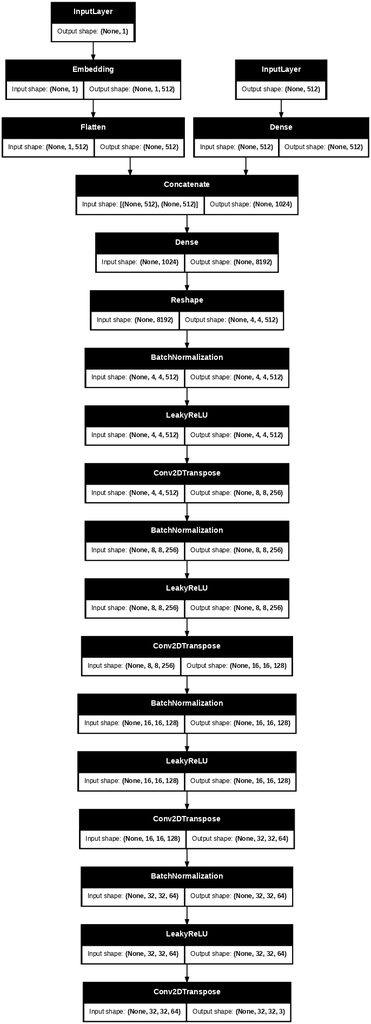

```python
# Initialize models
generator = build_generator()

generator.summary()
# Require extra packages to plot model
plot_model(generator, show_shapes=True, dpi=64)
```

## Create Discriminator model

```
Model: "functional_1"
```

```
┏━━━━━━━━━━━━━━━━━━━━━━━━━━━┳━━━━━━━━━━━━━━━━━━━━━━━━┳━━━━━━━━━━━━━━━━┳━━━━━━━━━━━━━━━━━━━━━━━━┓
┃ Layer (type)              ┃ Output Shape           ┃        Param # ┃ Connected to           ┃
┡━━━━━━━━━━━━━━━━━━━━━━━━━━━╇━━━━━━━━━━━━━━━━━━━━━━━━╇━━━━━━━━━━━━━━━━╇━━━━━━━━━━━━━━━━━━━━━━━━┩
│ input_layer_3             │ (None, 1)              │              0 │ -                      │
│ (InputLayer)              │                        │                │                        │
├───────────────────────────┼────────────────────────┼────────────────┼────────────────────────┤
│ embedding_1 (Embedding)   │ (None, 1, 3072)        │         30,720 │ input_layer_3[0][0]    │
├───────────────────────────┼────────────────────────┼────────────────┼────────────────────────┤
│ input_layer_2             │ (None, 32, 32, 3)      │              0 │ -                      │
│ (InputLayer)              │                        │                │                        │
├───────────────────────────┼────────────────────────┼────────────────┼────────────────────────┤
│ reshape_1 (Reshape)       │ (None, 32, 32, 3)      │              0 │ embedding_1[0][0]      │
├───────────────────────────┼────────────────────────┼────────────────┼────────────────────────┤
│ concatenate_1             │ (None, 32, 32, 6)      │              0 │ input_layer_2[0][0],   │
│ (Concatenate)             │                        │                │ reshape_1[0][0]        │
├───────────────────────────┼────────────────────────┼────────────────┼────────────────────────┤
│ conv2d (Conv2D)           │ (None, 16, 16, 64)     │          6,208 │ concatenate_1[0][0]    │
├───────────────────────────┼────────────────────────┼────────────────┼────────────────────────┤
│ leaky_re_lu_4 (LeakyReLU) │ (None, 16, 16, 64)     │              0 │ conv2d[0][0]           │
├───────────────────────────┼────────────────────────┼────────────────┼────────────────────────┤
│ conv2d_1 (Conv2D)         │ (None, 8, 8, 128)      │        131,200 │ leaky_re_lu_4[0][0]    │
├───────────────────────────┼────────────────────────┼────────────────┼────────────────────────┤
│ leaky_re_lu_5 (LeakyReLU) │ (None, 8, 8, 128)      │              0 │ conv2d_1[0][0]         │
├───────────────────────────┼────────────────────────┼────────────────┼────────────────────────┤
│ conv2d_2 (Conv2D)         │ (None, 4, 4, 256)      │        524,544 │ leaky_re_lu_5[0][0]    │
├───────────────────────────┼────────────────────────┼────────────────┼────────────────────────┤
│ leaky_re_lu_6 (LeakyReLU) │ (None, 4, 4, 256)      │              0 │ conv2d_2[0][0]         │
├───────────────────────────┼────────────────────────┼────────────────┼────────────────────────┤
│ flatten_1 (Flatten)       │ (None, 4096)           │              0 │ leaky_re_lu_6[0][0]    │
├───────────────────────────┼────────────────────────┼────────────────┼────────────────────────┤
│ dense_2 (Dense)           │ (None, 1)              │          4,097 │ flatten_1[0][0]        │
└───────────────────────────┴────────────────────────┴────────────────┴────────────────────────┘
```

```
 Total params: 696,769 (2.66 MB)
```

```
 Trainable params: 696,769 (2.66 MB)
```

```
 Non-trainable params: 0 (0.00 B)
```

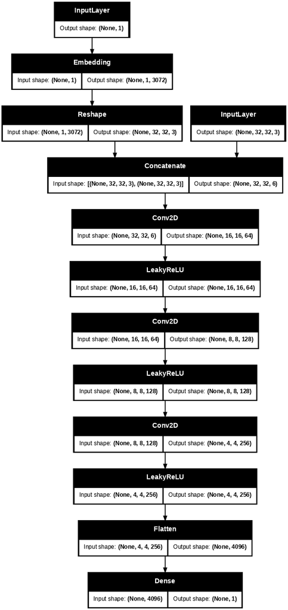

```python
discriminator = build_discriminator()

discriminator.summary()
# Require extra packages to plot model
plot_model(discriminator, show_shapes=True, dpi=64)
```

## define optimizer

```python
#d_optimizer = Adam(learning_rate=1e-4, beta_1=0.0, beta_2=0.9)
#g_optimizer = Adam(learning_rate=1e-4, beta_1=0.0, beta_2=0.9)

#d_optimizer = Adam(2e-5, beta_1=0.5, beta_2=0.9)
#g_optimizer = Adam(2e-5, beta_1=0.5, beta_2=0.9)

d_optimizer = tf.keras.optimizers.RMSprop(learning_rate=5e-5)
g_optimizer = tf.keras.optimizers.RMSprop(learning_rate=5e-5)
```

While Adam is a powerful and versatile optimizer, RMSprop's simpler adaptive learning rate can provide better stability and robustness in the challenging training environment of GANs, particularly WGAN-GP.

It is very important to remember that every situation can be different. So after trying different optimizers, RMSprom is providing more stable training.

```python
# Lipschitz Penalty Function
def lipschitz_penalty(discriminator, real_images, fake_images, labels):
    alpha = tf.random.uniform([real_images.shape[0], 1, 1, 1], 0., 1.)
    interpolated = alpha * real_images + (1 - alpha) * fake_images
    with tf.GradientTape() as tape:
        tape.watch(interpolated)
        pred_interpolated = discriminator([interpolated, labels], training=True)  # Pass labels
    gradients = tape.gradient(pred_interpolated, [interpolated])[0]
    #grad_norm = tf.sqrt(tf.reduce_sum(tf.square(gradients), axis=[1, 2, 3]))
    grad_norm = tf.sqrt(tf.reduce_sum(tf.square(gradients), axis=[1, 2, 3]) + 1e-8)  # Added stability
    penalty = LAMBDA * tf.reduce_mean(tf.square(tf.maximum(0.0, grad_norm - 1.0)))
    return penalty


# Discriminator Training Step
@tf.function
def train_discriminator(discriminator, generator, images, labels, optimizer):
    # Generate random noise and fake images
    noise = tf.random.normal([images.shape[0], NOISE_DIM])
    fake_images = generator([noise, labels], training=True)

    # Calculate discriminator loss using GradientTape
    with tf.GradientTape() as tape:
        # Optional: Label smoothing (not strictly necessary for WGAN-GP, but provides helps with better results)
        real_labels = tf.random.uniform([images.shape[0], 1], minval=0.8, maxval=1.0)
        fake_labels = tf.random.uniform([images.shape[0], 1], minval=0.0, maxval=0.2)

        # Pass real and fake images through the discriminator
        real_preds = discriminator([images, labels], training=True)
        fake_preds = discriminator([fake_images, labels], training=True)

        # Calculate Lipschitz penalty
        lp = lipschitz_penalty(discriminator, images, fake_images, labels)
        d_loss = tf.reduce_mean(fake_preds) - tf.reduce_mean(real_preds) + lp   # Calculate the discriminator loss (WGAN-GP loss)

    # Calculate gradients and apply them using the optimizer
    gradients = tape.gradient(d_loss, discriminator.trainable_variables)
    optimizer.apply_gradients(zip(gradients, discriminator.trainable_variables))
    return d_loss

# Generator Training Step
@tf.function
def train_generator(generator, discriminator, batch_size, optimizer):
    # Generate random noise and labels
    noise = tf.random.normal([batch_size, NOISE_DIM])
    labels = tf.random.uniform([batch_size, 1], minval=1, maxval=2, dtype=tf.int32)  # Only automobile class

    # Calculate generator loss using GradientTape
    with tf.GradientTape() as tape:
        # Generate fake images
        fake_images = generator([noise, labels], training=True)
        fake_preds = discriminator([fake_images, labels], training=True)    # Pass fake images through the discriminator

        # Calculate the generator loss (WGAN-GP loss)
        g_loss = -tf.reduce_mean(fake_preds)

    # Calculate gradients and apply them using the optimizer
    gradients = tape.gradient(g_loss, generator.trainable_variables)    #Calculate gradients.
    optimizer.apply_gradients(zip(gradients, generator.trainable_variables))  #Apply gradients using the optimizer.
    return g_loss
```

```python
# Generate and display images

def generate_images():
    with tf.device('/GPU:0'):   # Ensure execution on GPU if available
        noise = tf.random.normal([10, NOISE_DIM])   # Generate random noise vectors
        labels = tf.constant([[1]] * 10, dtype=tf.int32)    # Create labels for the "automobile" class (label 1)

        # Generate fake images using the generator (inference mode)
        fake_images = generator([noise, labels], training=False)
        fake_images = (fake_images + 1.0) / 2.0   # Scale the generated images from [-1, 1] to [0, 1]
        fake_images = (fake_images * 255).numpy().astype(np.uint8)    # Convert the images to uint8 for display

        # Display the generated images in a grid
        fig, axes = plt.subplots(1, 10, figsize=(15, 5))
        for i in range(10):
            axes[i].imshow(fake_images[i])
            axes[i].axis('off')
        plt.show()

        # Calculate FID score using the first 100 real images from x_train
        fid_score = compute_fid(x_train[:100], fake_images)
        # Calculate Inception Score
        inception_score, inception_std = compute_inception_score(fake_images)

        # Print the evaluation metrics
        print(f'FID Score: {fid_score}')
        print(f'Inception Score: {inception_score} ± {inception_std}')

#generate_images()
```

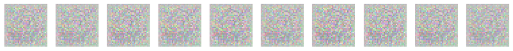

```
4/4 ━━━━━━━━━━━━━━━━━━━━ 11s 2s/step
1/1 ━━━━━━━━━━━━━━━━━━━━ 3s 3s/step
1/1 ━━━━━━━━━━━━━━━━━━━━ 6s 6s/step
FID Score: 417.936835497992
Inception Score: 1.0 ± 0.0
```

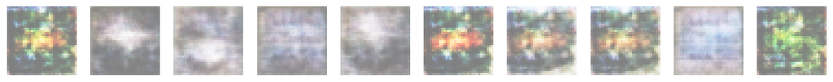

```
4/4 ━━━━━━━━━━━━━━━━━━━━ 12s 2s/step
1/1 ━━━━━━━━━━━━━━━━━━━━ 3s 3s/step
1/1 ━━━━━━━━━━━━━━━━━━━━ 5s 5s/step
FID Score: 508.0278356867448
Inception Score: 1.0 ± 0.0
```

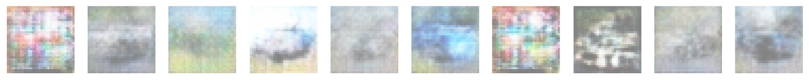

```
4/4 ━━━━━━━━━━━━━━━━━━━━ 11s 2s/step
1/1 ━━━━━━━━━━━━━━━━━━━━ 3s 3s/step
1/1 ━━━━━━━━━━━━━━━━━━━━ 6s 6s/step
FID Score: 531.6621870185086
Inception Score: 1.0 ± 0.0
```

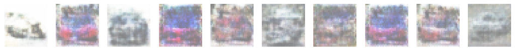

```
4/4 ━━━━━━━━━━━━━━━━━━━━ 11s 2s/step
1/1 ━━━━━━━━━━━━━━━━━━━━ 3s 3s/step
1/1 ━━━━━━━━━━━━━━━━━━━━ 5s 5s/step
FID Score: 565.0049621858167
Inception Score: 1.0 ± 0.0
```

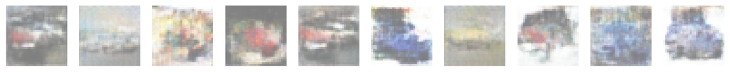

```
4/4 ━━━━━━━━━━━━━━━━━━━━ 12s 2s/step
1/1 ━━━━━━━━━━━━━━━━━━━━ 3s 3s/step
1/1 ━━━━━━━━━━━━━━━━━━━━ 6s 6s/step
FID Score: 603.7679256259854
Inception Score: 1.0 ± 0.0
```

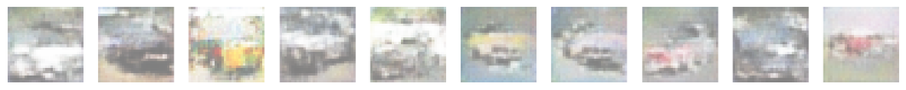

```
4/4 ━━━━━━━━━━━━━━━━━━━━ 11s 2s/step
1/1 ━━━━━━━━━━━━━━━━━━━━ 3s 3s/step
1/1 ━━━━━━━━━━━━━━━━━━━━ 5s 5s/step
FID Score: 593.9525064057673
Inception Score: 1.0 ± 0.0
```

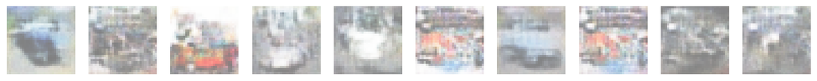

```
4/4 ━━━━━━━━━━━━━━━━━━━━ 12s 2s/step
1/1 ━━━━━━━━━━━━━━━━━━━━ 3s 3s/step
1/1 ━━━━━━━━━━━━━━━━━━━━ 6s 6s/step
FID Score: 596.7436169371836
Inception Score: 1.0 ± 0.0
```

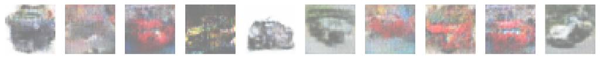

```
4/4 ━━━━━━━━━━━━━━━━━━━━ 11s 2s/step
1/1 ━━━━━━━━━━━━━━━━━━━━ 3s 3s/step
1/1 ━━━━━━━━━━━━━━━━━━━━ 6s 6s/step
FID Score: 575.0711878359623
Inception Score: 1.0 ± 0.0
```

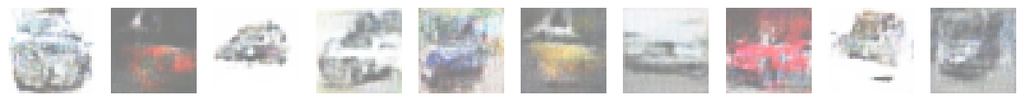

```
4/4 ━━━━━━━━━━━━━━━━━━━━ 11s 2s/step
1/1 ━━━━━━━━━━━━━━━━━━━━ 3s 3s/step
1/1 ━━━━━━━━━━━━━━━━━━━━ 7s 7s/step
FID Score: 593.6754254148143
Inception Score: 1.0 ± 0.0
```

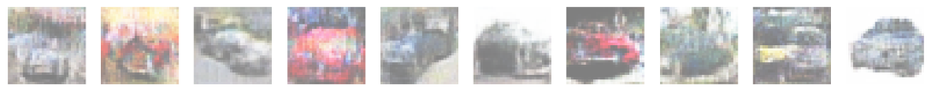

```
4/4 ━━━━━━━━━━━━━━━━━━━━ 11s 2s/step
1/1 ━━━━━━━━━━━━━━━━━━━━ 3s 3s/step
1/1 ━━━━━━━━━━━━━━━━━━━━ 5s 5s/step
FID Score: 650.9257451913803
Inception Score: 1.0 ± 0.0
```

```python
# Training Loop (WGAN-GP)

def train():
    for epoch in range(EPOCHS):
        for real_images, labels in dataset:
            d_loss = train_discriminator(discriminator, generator, real_images, labels, d_optimizer)
            g_loss = train_generator(generator, discriminator, BATCH_SIZE, g_optimizer)

        if epoch % 500 == 0:
            print(f"Epoch {epoch+1}/{EPOCHS}, D Loss: {d_loss.numpy()}, G Loss: {g_loss.numpy()}")
            generate_images()

train()
```

## Task 2, 3, 4 and 5 are implemented in another notebook. kindly refer the same